# GenderRecognition

Valentin Buisson

Louis Gaillet

Soilhat Mohamed

Sébastien Roques

2019-01-17

# Initialisation Dataset

First we needed to find a large dataset to train our models : we inally found it on the internet.

Each voice sample is stored as a .WAV file, which is then pre-processed for acoustic analysis using the specan function from the WarbleR R package. Specan measures 22 acoustic parameters on acoustic signals for which the start and end times are provided.

Let’s see the first sample :

```r
dataset <- read.csv("voice.csv")
dataset[1,]
```

```
##     meanfreq         sd     median        Q25        Q75        IQR
## 1 0.05978098 0.06424127 0.03202691 0.01507149 0.09019344 0.07512195
##       skew     kurt    sp.ent       sfm mode   centroid    meanfun
## 1 12.86346 274.4029 0.8933694 0.4919178    0 0.05978098 0.08427911
##       minfun    maxfun   meandom    mindom    maxdom dfrange modindx label
## 1 0.01570167 0.2758621 0.0078125 0.0078125 0.0078125       0       0  male
```

Here are the information we’ve got :

- duration: length of signal
- meanfreq: mean frequency (in kHz)
- sd: standard deviation of frequency
- median: median frequency (in kHz)
- Q25: first quantile (in kHz)
- Q75: third quantile (in kHz)
- IQR: interquantile range (in kHz)
- skew: skewness (see note in specprop description)
- kurt: kurtosis (see note in specprop description)
- sp.ent: spectral entropy
- sfm: spectral flatness
- mode: mode frequency
- centroid: frequency centroid (see specprop)
- peakf: peak frequency (frequency with highest energy)
- meanfun: average of fundamental frequency measured across acoustic signal
- minfun: minimum fundamental frequency measured across acoustic signal
- maxfun: maximum fundamental frequency measured across acoustic signal
- meandom: average of dominant frequency measured across acoustic signal
- mindom: minimum of dominant frequency measured across acoustic signal
- maxdom: maximum of dominant frequency measured across acoustic signal
- dfrange: range of dominant frequency measured across acoustic signal
- modindx: modulation index. Calculated as the accumulated absolute difference between adjacent measurements of fundamental frequencies divided by the frequency range

Now we need to split the dataset into 2 part : the training set and the test set.

```r
library(caTools);
set.seed('79')
split = sample.split(dataset$label, SplitRatio = 0.75)
training_set = subset(dataset, split == TRUE)
test_set = subset(dataset, split == FALSE)
```

# Logistic Regression

In our case we have a huge amount of informations and variables in our dataset. We new to find witch variables are the more efficient in a gender recognition. Instinctively, we can say that the frequency is a great indicator in this case. Let’s see if this is real by taking the average frequency measurement:

```r
summary(glm(formula = label ~ meandom, family = "binomial", data = training_set))
```

```
##
## Call:
## glm(formula = label ~ meandom, family = "binomial", data = training_set)
##
## Deviance Residuals:
##     Min       1Q   Median       3Q      Max
## -1.4361  -1.1665   0.1171   1.1342   1.8086
##
## Coefficients:
##             Estimate Std. Error z value Pr(>|z|)
## (Intercept)  0.59579    0.07947   7.497 6.51e-14 ***
## meandom     -0.71815    0.08217  -8.740  < 2e-16 ***
## ---
## Signif. codes:  0 '***' 0.001 '**' 0.01 '*' 0.05 '.' 0.1 ' ' 1
##
## (Dispersion parameter for binomial family taken to be 1)
##
##     Null deviance: 3293.8  on 2375  degrees of freedom
## Residual deviance: 3213.7  on 2374  degrees of freedom
## AIC: 3217.7
##
## Number of Fisher Scoring iterations: 4
```

```r
summary(glm(formula = label ~ ., family = "binomial", data = training_set))
```

```
##
## Call:
## glm(formula = label ~ ., family = "binomial", data = training_set)
##
## Deviance Residuals:
##     Min       1Q   Median       3Q      Max
## -3.1386  -0.0366   0.0003   0.1101   4.3393
##
## Coefficients: (3 not defined because of singularities)
##               Estimate Std. Error z value Pr(>|z|)
## (Intercept) -1.843e+01  1.088e+01  -1.694 0.090193 .
## meanfreq     4.330e+01  5.311e+01   0.815 0.414906
## sd           7.114e+01  4.109e+01   1.731 0.083375 .
## median      -2.252e+01  1.481e+01  -1.520 0.128497
## Q25         -5.198e+01  1.305e+01  -3.983 6.81e-05 ***
## Q75          2.753e+01  2.374e+01   1.160 0.246122
## IQR                 NA         NA      NA       NA
## skew         1.354e-02  1.874e-01   0.072 0.942402
## kurt        -4.263e-03  4.932e-03  -0.864 0.387358
## sp.ent       4.372e+01  1.190e+01   3.675 0.000238 ***
## sfm         -1.371e+01  2.987e+00  -4.588 4.48e-06 ***
## mode         4.507e+00  2.507e+00   1.798 0.072209 .
## centroid            NA         NA      NA       NA
## meanfun     -1.698e+02  1.022e+01 -16.610  < 2e-16 ***
## minfun       4.255e+01  1.041e+01   4.086 4.38e-05 ***
## maxfun      -1.592e-01  7.649e+00  -0.021 0.983397
## meandom     -3.115e-01  4.939e-01  -0.631 0.528218
## mindom      -2.750e-01  2.455e+00  -0.112 0.910823
## maxdom       2.753e-02  8.151e-02   0.338 0.735559
## dfrange             NA         NA      NA       NA
## modindx     -3.178e+00  1.830e+00  -1.737 0.082427 .
## ---
## Signif. codes:  0 '***' 0.001 '**' 0.01 '*' 0.05 '.' 0.1 ' ' 1
##
## (Dispersion parameter for binomial family taken to be 1)
##
##     Null deviance: 3293.8  on 2375  degrees of freedom
## Residual deviance:  424.4  on 2358  degrees of freedom
## AIC: 460.4
##
## Number of Fisher Scoring iterations: 8
```

We have here 8 significant properties that help define the gender. We decided to do the logistic regression on all the variables provided.

```r
model <- glm(formula = label ~ ., family = "binomial", data = training_set)
```

Once the model is done, we have to predict the gender on the test set and do a convolution matrix to observe the result

```r
predictor = predict(model, newdata = test_set, type="response")
```

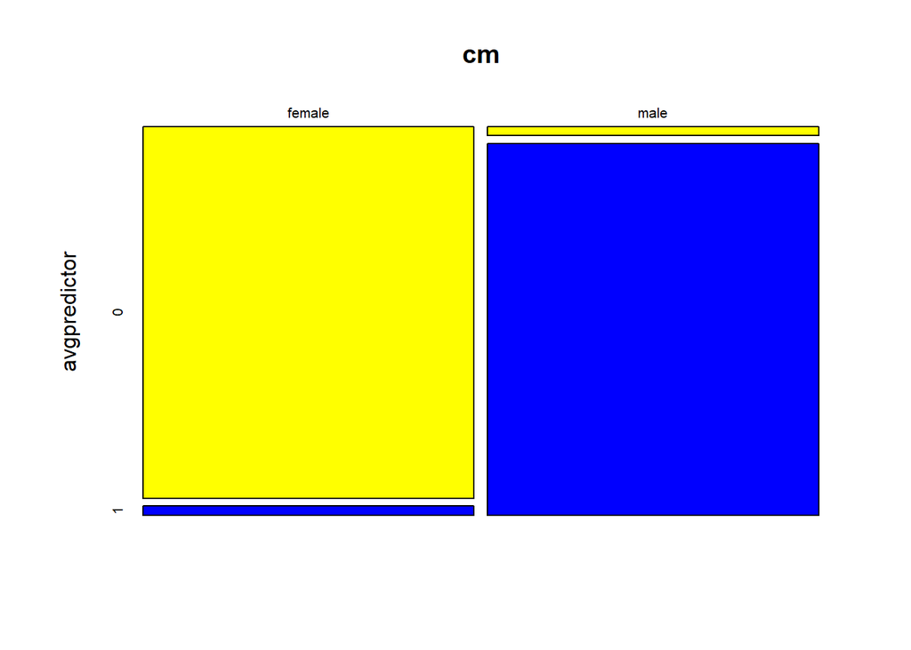

```r
avgpredictor = ifelse(predictor > 0.5, 1,0)
cm = table(test_set[,21], avgpredictor)
mosaicplot(cm,col=sample(1:8,2))
```

We can see that the model is very efficient with a **97%** accuracy. Let’s try this test with other models.

# Random Forest

```r
# install.packages("randomForest")
library(randomForest)
modelForest <- randomForest(label ~., data= training_set, ntree = 500, na.action = na.omit)
modelForest
```

```
##
## Call:
##  randomForest(formula = label ~ ., data = training_set, ntree = 500,      na.action = na.omit)
##                Type of random forest: classification
##                      Number of trees: 500
## No. of variables tried at each split: 4
##
##         OOB estimate of  error rate: 2.23%
## Confusion matrix:
##        female male class.error
## female   1163   25  0.02104377
## male       28 1160  0.02356902
```

Here we specify with the parameter *na.action = na.omit* to omit the unknown values. We find an error rate of 2% so a **98 %** accuracy on the training set, the result is similar as the model with Logistic Regression.

Now lets do a prediction:

```r
cmF <- table(predict(modelForest, test_set), test_set$label)
(cmF[1,1] + cmF[2,2]) / sum(cmF) # accuracy
```

```
## [1] 0.9810606
```

We find a 98% accuracy on the test set.